# Überblick_SGB

### Installiere package “heven” um Daten einzulesen

```r
pacman::p_load(haven)
```

### Lese Daten SGB (2007, 2012, 2017) ein

```r
setwd("C:/Users/gerbe/Desktop/Desktopordner/Master/Transfer I/Daten")
dat <- read_dta("shs_2007_2012_2017_combined.dta")
```

### Teile Datensatz nach Jahr auf (intjahr)

```r
dat_07 <- subset(dat, intjahr == 2007)
dat_12 <- subset(dat, intjahr == 2012)
dat_17 <- subset(dat, intjahr == 2017)
```

## Frage: Müsste ich hier jetzt auch nochmals ein subset (Untergruppe) machen für?

- == 0 (Nur telefonisches Interview)

```r
head(dat_07$tel_sfb)
```

```
## <labelled<double>[6]>: Teilnahme Telefoninterview und schriftlicher Fragebogen
## [1] 0 1 1 1 1 1
##
## Labels:
##  value                                      label
##     -9         Keine Antwort zum Frageblock (sfb)
##     -8                      Keine Übereinstimmung
##     -6                                      PROXY
##     -5          Mehrfachantwort, nicht ausgewählt
##     -4                        Fehler in den Daten
##     -3                     Nicht gefragt (Filter)
##     -2                              Keine Antwort
##     -1                                Weiss nicht
##      0                Nur telefonisches Interview
##      1 Telefonischer UND schriftlicher Fragebogen
##      2                Nur telefonisches Interview
##  NA(a)                                Weiss nicht
##  NA(b)                              Keine Antwort
##  NA(c)                     Nicht gefragt (Filter)
##  NA(d)                        Fehler in den Daten
##  NA(e)          Mehrfachantwort, nicht ausgewählt
##  NA(f)                                      PROXY
##  NA(g)                      Keine Übereinstimmung
##  NA(h)         Keine Antwort zum Frageblock (sfb)
```

```r
table(dat_07$tel_sfb)
```

```
##
##     0     1
##  3538 14393
```

```r
head(dat_07$sfbtyp)
```

```
## <labelled<double>[6]>: Fragebogen: Typ
## [1] NA  1  1  1  1  2
##
## Labels:
##  value                              label
##     -9 Keine Antwort zum Frageblock (sfb)
##     -8              Keine Übereinstimmung
##     -6                              PROXY
##     -5  Mehrfachantwort, nicht ausgewählt
##     -4                Fehler in den Daten
##     -3             Nicht gefragt (Filter)
##     -2                      Keine Antwort
##     -1                        Weiss nicht
##      1                             Papier
##      2                             Online
##  NA(a)                        Weiss nicht
##  NA(b)                      Keine Antwort
##  NA(c)             Nicht gefragt (Filter)
##  NA(d)                Fehler in den Daten
##  NA(e)  Mehrfachantwort, nicht ausgewählt
##  NA(f)                              PROXY
##  NA(g)              Keine Übereinstimmung
##  NA(h) Keine Antwort zum Frageblock (sfb)
```

```r
table(dat_07$sfbtyp)
```

```
##
##     1     2
## 12936  1457
```

## Überblick: Population und Gewichtung

### R packages für Survey-Analyse

```r
pacman::p_load(ggplot2, dplyr, survey, hexbin)
```

## Der Datensatz hat Gewichtungvariable für jede Erfassungsart

- TEL17_CH: 22’134 Fälle mit 450 Variablen. Die Daten enthalten auch die Gewichtungsvariable **«wght»**. Variablenlabes, Fragebogen und Filterführung befinden sich unter B_Dokumentation.
- SFB17_CH: 18’832 Fälle mit 252 Variablen. Die Daten enthalten auch die Gewichtungsvariable **«wecrit»**. Variablenlabels und Fragebogen befinden sich unter B_Dokumentation.

```r
head(dat_07$wecrit)
```

```
## [1]       NA 217.4600 178.7872 346.2336 453.6107 367.3874
```

```r
head(dat_07$wght)
```

```
## [1] 205.8879 180.1187 132.6808 315.0558 341.8308 272.9284
```

### Observationen (befragete Personen), Variablen

```r
dim(dat_07)
```

```
## [1] 18760  1689
```

### Anzahl Personen Population

```r
summarize(dat_07, N_hat = sum(wght))
```

```
## # A tibble: 1 x 1
##      N_hat
##      <dbl>
## 1 6186711.
```

### Tabelle der Durchschnittsgewichtung in den Kanton

```r
tab_weights_kanton <- dat_07 %>%
  group_by(kanton) %>%
  summarize(avg_wt = mean(wght))
```

### Anzahl clusters = Anzahl Personen (hat keine Cluster)

```r
dat_07 %>%
  summarize(n_clusters = n_distinct(idno, kanton))
```

```
## # A tibble: 1 x 1
##   n_clusters
##        <int>
## 1      18760
```

### Wenn es clusters gäbe würde der Code die “sample sizes in clusters” wiedergeben (*n*=1)

```r
dat_07 %>%
  count(kanton, idno)
```

```
## # A tibble: 18,760 x 3
##        kanton  idno     n
##     <dbl+lbl> <dbl> <int>
##  1 1 [Zürich]   254     1
##  2 1 [Zürich]   255     1
##  3 1 [Zürich]   256     1
##  4 1 [Zürich]   258     1
##  5 1 [Zürich]   265     1
##  6 1 [Zürich]   266     1
##  7 1 [Zürich]   267     1
##  8 1 [Zürich]   268     1
##  9 1 [Zürich]   269     1
## 10 1 [Zürich]   272     1
## # ... with 18,750 more rows
```

### Ausgabe Tabelle der Durchschnittsgewichtung in den Kanton

```r
tab_weights_kanton
```

```
## # A tibble: 27 x 2
##                      kanton avg_wt
##                   <dbl+lbl>  <dbl>
##  1  1 [Zürich]               431.
##  2  2 [Bern / Berne]         327.
##  3  3 [Luzern]               267.
##  4  4 [Uri]                   59.4
##  5  5 [Schwyz]               175.
##  6  6 [Obwalden]             578.
##  7  7 [Nidwalden]            496.
##  8  8 [Glarus]               386.
##  9  9 [Zug]                  520.
## 10 10 [Fribourg / Freiburg]  198.
## # ... with 17 more rows
```

## Überblick Veriablen

### Bearbeite Variablen (faktorisieren: levels(), labels())

- Geschlecht

```r
dat_07$sex.f <- factor(dat_07$sex,
       levels = c(1,2),
       labels = c("Mann", "Frau"))
levels(dat_07$sex.f)
```

```
## [1] "Mann" "Frau"
```

- Kantone

```r
dat_07$kanton.f <- factor(dat_07$kanton,
                          levels = c(1:27),
                          labels = c("Zürich", "Bern / Berne", "Luzern","Uri", "Schwyz","Obwalden",
"Nidwalden","Glarus","Zug","Fribourg / Freiburg","Solothurn","Basel-Stadt","Basel-Landschaft","Schaffhausen","Appenzell Ausserrhoden",
"Appenzell Innerrhoden","St. Gallen","Graubünden / Grigioni / Grischun","Aargau","Thurgau","Ticino","Vaud","Valais / Wallis","Neuchâtel",
"Genève","Jura","Liechstenstein"))
levels(dat_07$kanton.f)
```

```
##  [1] "Zürich"                           "Bern / Berne"
##  [3] "Luzern"                           "Uri"
##  [5] "Schwyz"                           "Obwalden"
##  [7] "Nidwalden"                        "Glarus"
##  [9] "Zug"                              "Fribourg / Freiburg"
## [11] "Solothurn"                        "Basel-Stadt"
## [13] "Basel-Landschaft"                 "Schaffhausen"
## [15] "Appenzell Ausserrhoden"           "Appenzell Innerrhoden"
## [17] "St. Gallen"                       "Graubünden / Grigioni / Grischun"
## [19] "Aargau"                           "Thurgau"
## [21] "Ticino"                           "Vaud"
## [23] "Valais / Wallis"                  "Neuchâtel"
## [25] "Genève"                           "Jura"
## [27] "Liechstenstein"
```

- Sturz in den letzten 12 Monaten (taltp01)

```r
dat_07$taltp01.f <- factor(dat_07$taltp01,
                          levels = c(1,2),
                          labels = c("Sturz letzte 12 Monate", "kein Sturz letzte 12 Monate"))
levels(dat_07$taltp01.f)
```

```
## [1] "Sturz letzte 12 Monate"      "kein Sturz letzte 12 Monate"
```

- Anzahl Stürze letzte 12 Monate (taltp02)

```r
dat_07$taltp02.f <- factor(dat_07$taltp02,
                           levels = c(1,2,3),
                           labels = c("1 Sturz letzte 12 Monate", "2 Stürze letzte 12 Monate", "Mehr als 2 Stürze letzte 12 Monate"))
levels(dat_07$taltp02.f)
```

```
## [1] "1 Sturz letzte 12 Monate"           "2 Stürze letzte 12 Monate"
## [3] "Mehr als 2 Stürze letzte 12 Monate"
```

- weitere Variablen folgen…

## Surveydesign

### Entferne fehlende Daten (*NA’s*) in “Stratum”, damit Surveyobjekt erstellt werden kann

```r
dat_07 <- subset( dat_07 , !is.na( kanton ) )
```

- Frage: Ist diese Entfernung korrekt?

### Spezifizierung des Surveydesign; Gewichtung setzen

```r
wdat_07<-svydesign(id = ~idno, strata = ~kanton, weights = ~wght, nest = T, data = dat_07)
```

### Häufigkeitstabelle “Geschlecht”

```r
tab_g <- svytable(~sex.f, design =wdat_07)
```

- Klasse von tab_g

```r
class(tab_g)
```

```
## [1] "svytable" "xtabs"    "table"
```

- Anzeige tab_g

```r
tab_g
```

```
## sex.f
##    Mann    Frau
## 2181140 2402680
```

- Proportionen zur Tabelle hinzufügen

```r
tab_g <- tab_g %>%
  as.data.frame() %>%
  mutate(Prop = Freq/sum(Freq))
tab_g
```

```
##   sex.f    Freq      Prop
## 1  Mann 2181140 0.4758346
## 2  Frau 2402680 0.5241654
```

### Eine Balkengrafik erstellen

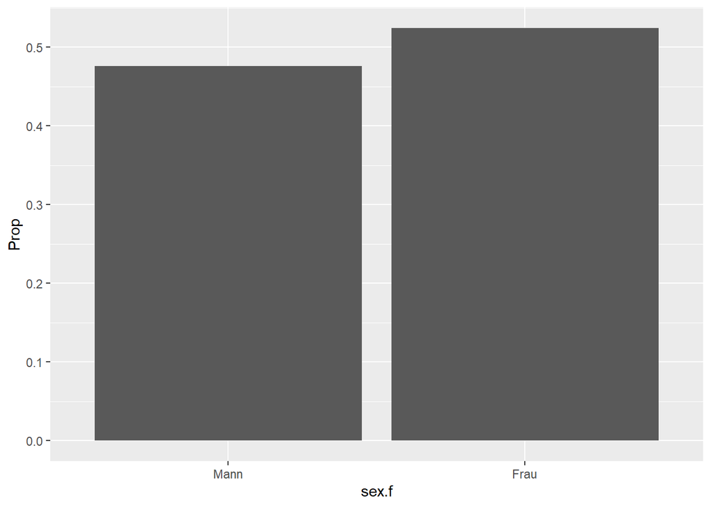

```r
ggplot(data = tab_g,
       mapping = aes(x = sex.f, y = Prop)) +
  geom_col()
```

### Konstruieren und Anzeigen einer Frequenztabelle

```r
tab_D <- svytable(~kanton.f+sex.f,
                  design = wdat_07)
tab_D
```

```
##                                   sex.f
## kanton.f                                 Mann       Frau
##   Zürich                           389506.733 414440.191
##   Bern / Berne                     281534.040 315719.170
##   Luzern                            98144.239 123673.734
##   Uri                               10465.285  10625.704
##   Schwyz                            36510.244  43085.490
##   Obwalden                           9457.228  13655.129
##   Nidwalden                         11722.622  17072.077
##   Glarus                            14188.133   7059.406
##   Zug                               27719.582  34148.572
##   Fribourg / Freiburg               71406.806  81887.676
##   Solothurn                         73891.926  84660.059
##   Basel-Stadt                       54681.406  68079.453
##   Basel-Landschaft                  77558.021  94202.685
##   Schaffhausen                      18312.128  25555.399
##   Appenzell Ausserrhoden            14564.828  18143.862
##   Appenzell Innerrhoden              2335.169   3680.170
##   St. Gallen                       125629.008 134914.489
##   Graubünden / Grigioni / Grischun  81362.766  61775.453
##   Aargau                           163266.316 179126.647
##   Thurgau                           67660.519  66973.373
##   Ticino                            88429.494 105857.380
##   Vaud                             196184.927 202846.599
##   Valais / Wallis                   83321.724  95720.996
##   Neuchâtel                         48618.434  55558.242
##   Genève                           113239.884 123247.745
##   Jura                              21428.695  20970.108
##   Liechstenstein                        0.000      0.000
```

### Bedingte Proportionen zu tab_DH hinzufügen

```r
tab_D_cond <- tab_D %>%
  as.data.frame() %>%
  group_by(kanton.f) %>%
  mutate(n_Kanton.f = sum(Freq), Prop_sex = Freq/n_Kanton.f) %>%
  ungroup()
tab_D_cond
```

```
## # A tibble: 54 x 5
##    kanton.f            sex.f    Freq n_Kanton.f Prop_sex
##    <fct>               <fct>   <dbl>      <dbl>    <dbl>
##  1 Zürich              Mann  389507.    803947.    0.484
##  2 Bern / Berne        Mann  281534.    597253.    0.471
##  3 Luzern              Mann   98144.    221818.    0.442
##  4 Uri                 Mann   10465.     21091.    0.496
##  5 Schwyz              Mann   36510.     79596.    0.459
##  6 Obwalden            Mann    9457.     23112.    0.409
##  7 Nidwalden           Mann   11723.     28795.    0.407
##  8 Glarus              Mann   14188.     21248.    0.668
##  9 Zug                 Mann   27720.     61868.    0.448
## 10 Fribourg / Freiburg Mann   71407.    153294.    0.466
## # ... with 44 more rows
```

### Create a segmented bar graph of the conditional proportions in tab_DH_cond

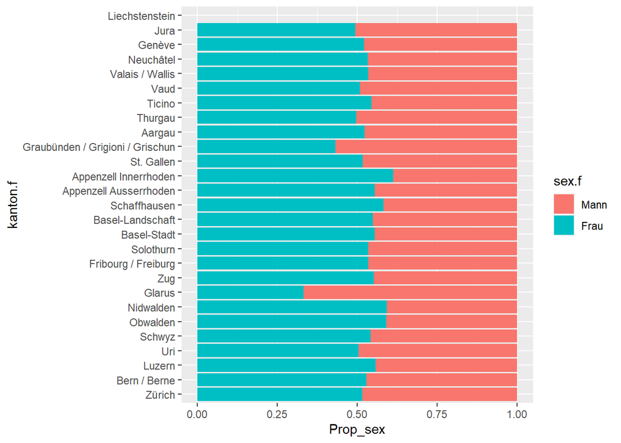

```r
ggplot(data = tab_D_cond,
       mapping = aes(x = kanton.f, y = Prop_sex, fill = sex.f)) +
  geom_col() +
  coord_flip()
```

### Schätzen Sie die Gesamtzahlen für Kombination von Geschlecht und Kanton

```r
tab_totals <- svytotal(x = ~interaction(sex.f, kanton.f),
                       design = wdat_07,
                       na.rm = TRUE)
tab_totals
```

```
##                                                                      total
## interaction(sex.f, kanton.f)Mann.Zürich                           389506.7
## interaction(sex.f, kanton.f)Frau.Zürich                           414440.2
## interaction(sex.f, kanton.f)Mann.Bern / Berne                     281534.0
## interaction(sex.f, kanton.f)Frau.Bern / Berne                     315719.2
## interaction(sex.f, kanton.f)Mann.Luzern                            98144.2
## interaction(sex.f, kanton.f)Frau.Luzern                           123673.7
## interaction(sex.f, kanton.f)Mann.Uri                               10465.3
## interaction(sex.f, kanton.f)Frau.Uri                               10625.7
## interaction(sex.f, kanton.f)Mann.Schwyz                            36510.2
## interaction(sex.f, kanton.f)Frau.Schwyz                            43085.5
## interaction(sex.f, kanton.f)Mann.Obwalden                           9457.2
## interaction(sex.f, kanton.f)Frau.Obwalden                          13655.1
## interaction(sex.f, kanton.f)Mann.Nidwalden                         11722.6
## interaction(sex.f, kanton.f)Frau.Nidwalden                         17072.1
## interaction(sex.f, kanton.f)Mann.Glarus                            14188.1
## interaction(sex.f, kanton.f)Frau.Glarus                             7059.4
## interaction(sex.f, kanton.f)Mann.Zug                               27719.6
## interaction(sex.f, kanton.f)Frau.Zug                               34148.6
## interaction(sex.f, kanton.f)Mann.Fribourg / Freiburg               71406.8
## interaction(sex.f, kanton.f)Frau.Fribourg / Freiburg               81887.7
## interaction(sex.f, kanton.f)Mann.Solothurn                         73891.9
## interaction(sex.f, kanton.f)Frau.Solothurn                         84660.1
## interaction(sex.f, kanton.f)Mann.Basel-Stadt                       54681.4
## interaction(sex.f, kanton.f)Frau.Basel-Stadt                       68079.5
## interaction(sex.f, kanton.f)Mann.Basel-Landschaft                  77558.0
## interaction(sex.f, kanton.f)Frau.Basel-Landschaft                  94202.7
## interaction(sex.f, kanton.f)Mann.Schaffhausen                      18312.1
## interaction(sex.f, kanton.f)Frau.Schaffhausen                      25555.4
## interaction(sex.f, kanton.f)Mann.Appenzell Ausserrhoden            14564.8
## interaction(sex.f, kanton.f)Frau.Appenzell Ausserrhoden            18143.9
## interaction(sex.f, kanton.f)Mann.Appenzell Innerrhoden              2335.2
## interaction(sex.f, kanton.f)Frau.Appenzell Innerrhoden              3680.2
## interaction(sex.f, kanton.f)Mann.St. Gallen                       125629.0
## interaction(sex.f, kanton.f)Frau.St. Gallen                       134914.5
## interaction(sex.f, kanton.f)Mann.Graubünden / Grigioni / Grischun  81362.8
## interaction(sex.f, kanton.f)Frau.Graubünden / Grigioni / Grischun  61775.5
## interaction(sex.f, kanton.f)Mann.Aargau                           163266.3
## interaction(sex.f, kanton.f)Frau.Aargau                           179126.6
## interaction(sex.f, kanton.f)Mann.Thurgau                           67660.5
```

[output cut: 55 more lines]

```
## interaction(sex.f, kanton.f)Frau.Thurgau                           4751.00
## interaction(sex.f, kanton.f)Mann.Ticino                            3861.20
## interaction(sex.f, kanton.f)Frau.Ticino                            3626.49
## interaction(sex.f, kanton.f)Mann.Vaud                              7890.04
## interaction(sex.f, kanton.f)Frau.Vaud                              7339.38
## interaction(sex.f, kanton.f)Mann.Valais / Wallis                   4421.33
## interaction(sex.f, kanton.f)Frau.Valais / Wallis                   3898.21
## interaction(sex.f, kanton.f)Mann.Neuchâtel                         3234.32
## interaction(sex.f, kanton.f)Frau.Neuchâtel                         2691.24
## interaction(sex.f, kanton.f)Mann.Genève                            5756.96
## interaction(sex.f, kanton.f)Frau.Genève                            5645.34
## interaction(sex.f, kanton.f)Mann.Jura                              1329.04
## interaction(sex.f, kanton.f)Frau.Jura                              1319.23
## interaction(sex.f, kanton.f)Mann.Liechstenstein                       0.00
## interaction(sex.f, kanton.f)Frau.Liechstenstein                       0.00
```

### Schätzen des Mittelwerts der Kombination von Geschlecht und Kanton

```r
tab_means <- svymean(x = ~interaction(sex.f, kanton.f),
                     design = wdat_07,
                     na.rm = TRUE)
tab_means
```

```
##                                                                         mean
## interaction(sex.f, kanton.f)Mann.Zürich                           0.08497426
## interaction(sex.f, kanton.f)Frau.Zürich                           0.09041371
## interaction(sex.f, kanton.f)Mann.Bern / Berne                     0.06141909
## interaction(sex.f, kanton.f)Frau.Bern / Berne                     0.06887687
## interaction(sex.f, kanton.f)Mann.Luzern                           0.02141102
## interaction(sex.f, kanton.f)Frau.Luzern                           0.02698050
## interaction(sex.f, kanton.f)Mann.Uri                              0.00228309
## interaction(sex.f, kanton.f)Frau.Uri                              0.00231809
## interaction(sex.f, kanton.f)Mann.Schwyz                           0.00796503
## interaction(sex.f, kanton.f)Frau.Schwyz                           0.00939947
## interaction(sex.f, kanton.f)Mann.Obwalden                         0.00206318
## interaction(sex.f, kanton.f)Frau.Obwalden                         0.00297898
## interaction(sex.f, kanton.f)Mann.Nidwalden                        0.00255739
## interaction(sex.f, kanton.f)Frau.Nidwalden                        0.00372442
## interaction(sex.f, kanton.f)Mann.Glarus                           0.00309526
## interaction(sex.f, kanton.f)Frau.Glarus                           0.00154007
## interaction(sex.f, kanton.f)Mann.Zug                              0.00604727
## interaction(sex.f, kanton.f)Frau.Zug                              0.00744981
## interaction(sex.f, kanton.f)Mann.Fribourg / Freiburg              0.01557801
## interaction(sex.f, kanton.f)Frau.Fribourg / Freiburg              0.01786451
## interaction(sex.f, kanton.f)Mann.Solothurn                        0.01612016
## interaction(sex.f, kanton.f)Frau.Solothurn                        0.01846932
## interaction(sex.f, kanton.f)Mann.Basel-Stadt                      0.01192922
## interaction(sex.f, kanton.f)Frau.Basel-Stadt                      0.01485212
## interaction(sex.f, kanton.f)Mann.Basel-Landschaft                 0.01691995
## interaction(sex.f, kanton.f)Frau.Basel-Landschaft                 0.02055113
## interaction(sex.f, kanton.f)Mann.Schaffhausen                     0.00399495
## interaction(sex.f, kanton.f)Frau.Schaffhausen                     0.00557513
## interaction(sex.f, kanton.f)Mann.Appenzell Ausserrhoden           0.00317744
## interaction(sex.f, kanton.f)Frau.Appenzell Ausserrhoden           0.00395824
## interaction(sex.f, kanton.f)Mann.Appenzell Innerrhoden            0.00050944
## interaction(sex.f, kanton.f)Frau.Appenzell Innerrhoden            0.00080286
## interaction(sex.f, kanton.f)Mann.St. Gallen                       0.02740706
## interaction(sex.f, kanton.f)Frau.St. Gallen                       0.02943276
## interaction(sex.f, kanton.f)Mann.Graubünden / Grigioni / Grischun 0.01774999
## interaction(sex.f, kanton.f)Frau.Graubünden / Grigioni / Grischun 0.01347685
## interaction(sex.f, kanton.f)Mann.Aargau                           0.03561796
## interaction(sex.f, kanton.f)Frau.Aargau                           0.03907803
## interaction(sex.f, kanton.f)Mann.Thurgau                          0.01476073
```

[output cut: 55 more lines]

```
## interaction(sex.f, kanton.f)Frau.Thurgau                          0.0010
## interaction(sex.f, kanton.f)Mann.Ticino                           0.0008
## interaction(sex.f, kanton.f)Frau.Ticino                           0.0008
## interaction(sex.f, kanton.f)Mann.Vaud                             0.0017
## interaction(sex.f, kanton.f)Frau.Vaud                             0.0016
## interaction(sex.f, kanton.f)Mann.Valais / Wallis                  0.0010
## interaction(sex.f, kanton.f)Frau.Valais / Wallis                  0.0009
## interaction(sex.f, kanton.f)Mann.Neuchâtel                        0.0007
## interaction(sex.f, kanton.f)Frau.Neuchâtel                        0.0006
## interaction(sex.f, kanton.f)Mann.Genève                           0.0013
## interaction(sex.f, kanton.f)Frau.Genève                           0.0012
## interaction(sex.f, kanton.f)Mann.Jura                             0.0003
## interaction(sex.f, kanton.f)Frau.Jura                             0.0003
## interaction(sex.f, kanton.f)Mann.Liechstenstein                   0.0000
## interaction(sex.f, kanton.f)Frau.Liechstenstein                   0.0000
```

### Konstruieren und Anzeigen einer Frequenztabelle der Stürze je Kanton

```r
tab_taltp01 <- svytable(~taltp01.f + kanton.f,
                  design = wdat_07)
tab_taltp01
```

```
##                              kanton.f
## taltp01.f                          Zürich Bern / Berne      Luzern         Uri
##   Sturz letzte 12 Monate       62422.4406   37073.0315  12880.3657   1207.6427
##   kein Sturz letzte 12 Monate 161153.1651  111518.2216  38348.7401   4163.1386
##                              kanton.f
## taltp01.f                          Schwyz    Obwalden   Nidwalden      Glarus
##   Sturz letzte 12 Monate        4043.1318   1204.5645    612.9783    469.1721
##   kein Sturz letzte 12 Monate  11672.8906   5088.2429   5627.0333   3869.3350
##                              kanton.f
## taltp01.f                             Zug Fribourg / Freiburg   Solothurn
##   Sturz letzte 12 Monate        4127.0916           6756.2639  11205.4519
##   kein Sturz letzte 12 Monate  11697.8161          21911.6154  32769.0977
##                              kanton.f
## taltp01.f                     Basel-Stadt Basel-Landschaft Schaffhausen
##   Sturz letzte 12 Monate        7932.4231       11154.3664    4124.4791
##   kein Sturz letzte 12 Monate  31031.5407       50008.3545   11165.7325
##                              kanton.f
## taltp01.f                     Appenzell Ausserrhoden Appenzell Innerrhoden
##   Sturz letzte 12 Monate                   1678.5504                0.0000
##   kein Sturz letzte 12 Monate              6068.9284             1434.0175
##                              kanton.f
## taltp01.f                      St. Gallen Graubünden / Grigioni / Grischun
##   Sturz letzte 12 Monate       11579.8624                        8450.5106
##   kein Sturz letzte 12 Monate  52803.9676                       29338.0505
##                              kanton.f
## taltp01.f                          Aargau     Thurgau      Ticino        Vaud
##   Sturz letzte 12 Monate       23770.8957   5298.6943   8987.8716  24519.1904
##   kein Sturz letzte 12 Monate  67355.7943  27734.7470  49404.0064  80619.5346
##                              kanton.f
## taltp01.f                     Valais / Wallis   Neuchâtel      Genève
##   Sturz letzte 12 Monate            9351.1886   7164.8976  13140.0883
##   kein Sturz letzte 12 Monate      32713.9630  23642.0873  49478.0848
##                              kanton.f
## taltp01.f                            Jura Liechstenstein
##   Sturz letzte 12 Monate        1491.4529         0.0000
##   kein Sturz letzte 12 Monate   6816.4946         0.0000
```

### Addieren des bedingten Anteil der Stürze (taltp01) für jeden Kanton

```r
tab_taltp01_prop <- as.data.frame(tab_taltp01) %>%
  group_by(kanton.f) %>%
  mutate(n_kanton.f = sum(Freq), Prop_n.kanton.f = Freq / n_kanton.f) %>%
  ungroup()

tab_taltp01_prop
```

```
## # A tibble: 54 x 5
##    taltp01.f                   kanton.f        Freq n_kanton.f Prop_n.kanton.f
##    <fct>                       <fct>          <dbl>      <dbl>           <dbl>
##  1 Sturz letzte 12 Monate      Zürich        62422.    223576.           0.279
##  2 kein Sturz letzte 12 Monate Zürich       161153.    223576.           0.721
##  3 Sturz letzte 12 Monate      Bern / Berne  37073.    148591.           0.249
##  4 kein Sturz letzte 12 Monate Bern / Berne 111518.    148591.           0.751
##  5 Sturz letzte 12 Monate      Luzern        12880.     51229.           0.251
##  6 kein Sturz letzte 12 Monate Luzern        38349.     51229.           0.749
##  7 Sturz letzte 12 Monate      Uri            1208.      5371.           0.225
##  8 kein Sturz letzte 12 Monate Uri            4163.      5371.           0.775
##  9 Sturz letzte 12 Monate      Schwyz         4043.     15716.           0.257
## 10 kein Sturz letzte 12 Monate Schwyz        11673.     15716.           0.743
## # ... with 44 more rows
```

### Erstellen eines segmentierten Balkendiagramms

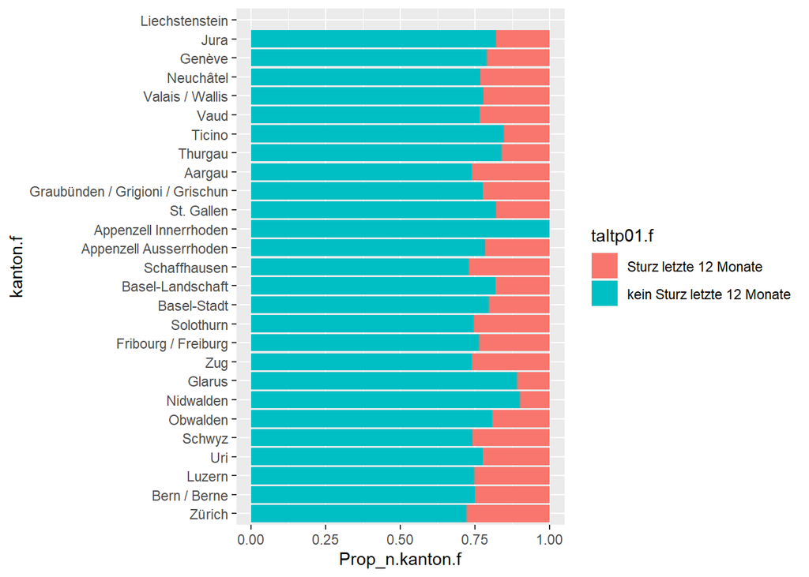

```r
ggplot(data = tab_taltp01_prop, mapping = aes(x = kanton.f, y = Prop_n.kanton.f, fill = taltp01.f)) +
  geom_col() +
  coord_flip()
```

### Chi-Quadrat-Test zwischen taltp01 (Sturz letzte 12M) und Geschlecht

```r
svychisq(~taltp01.f + sex.f,
         design = wdat_07,
         statistic = "Chisq")
```

[output not shown]

### Berechnung des umfragegewichteten Mittelwerts (taltp02, Anzahl Stürze letzte 12 Monate = *1, 2 oder 3≤)

```r
svymean(x = ~taltp02.f,
        design = wdat_07,
        na.rm = TRUE)
```

```
##                                                mean     SE
## taltp02.f1 Sturz letzte 12 Monate           0.66503 0.0174
## taltp02.f2 Stürze letzte 12 Monate          0.17624 0.0137
## taltp02.fMehr als 2 Stürze letzte 12 Monate 0.15873 0.0135
```

### Berechnung des umfragegewichteten Mittelwerts *taltp02* nach Geschlecht ü60

```r
svyby(formula = ~taltp02.f,
      by = ~sex.f,
      design = subset(wdat_07, alter >= 60),
      FUN = svymean,
      na.rm = TRUE,
      keep.names = FALSE)
```

```
##   sex.f taltp02.f1 Sturz letzte 12 Monate taltp02.f2 Stürze letzte 12 Monate
## 1  Mann                         0.6581897                          0.1729748
## 2  Frau                         0.6699325                          0.1785720
##   taltp02.fMehr als 2 Stürze letzte 12 Monate
## 1                                   0.1688355
## 2                                   0.1514955
##   se.taltp02.f1 Sturz letzte 12 Monate se.taltp02.f2 Stürze letzte 12 Monate
## 1                           0.02896072                            0.02245914
## 2                           0.02153024                            0.01725674
##   se.taltp02.fMehr als 2 Stürze letzte 12 Monate
## 1                                     0.02275675
## 2                                     0.01648720
```

### Berechnung der umfragegewichteten Quantilen des bmi

```r
svyquantile(x = ~bmi,
            design = subset(wdat_07, alter >= 60),
            na.rm = TRUE,
            quantiles = c(0.01, 0.25, 0.5, 0.75, .99))
```

```
##         0.01     0.25      0.5     0.75    0.99
## bmi 17.71542 22.67574 24.97399 27.39818 36.7427
```

### Berechnung der survey-gewichteten Quantilen des bmi nach Geschlecht ü60

```r
svyby(formula = ~bmi,
      by = ~sex.f,
      design = subset(wdat_07, alter >= 60),
      FUN = svyquantile,
      na.rm = TRUE,
      quantiles =  0.5,
      keep.rows = FALSE,
      keep.var = FALSE)
```

```
##      sex.f statistic
## Mann  Mann  25.53545
## Frau  Frau  24.23823
```

### Berechnnung der survey-gewichteten Mittelwerte des bmi nach Geschlecht ü60

```r
out<-svyby(formula = ~bmi,
           by = ~sex.f,
           design = subset(wdat_07, alter >= 60),
           FUN = svymean,
           na.rm = TRUE,
           keep.names = FALSE)
```

### Balkendiagramm des durchschnittlichen bmi nach Geschlecht

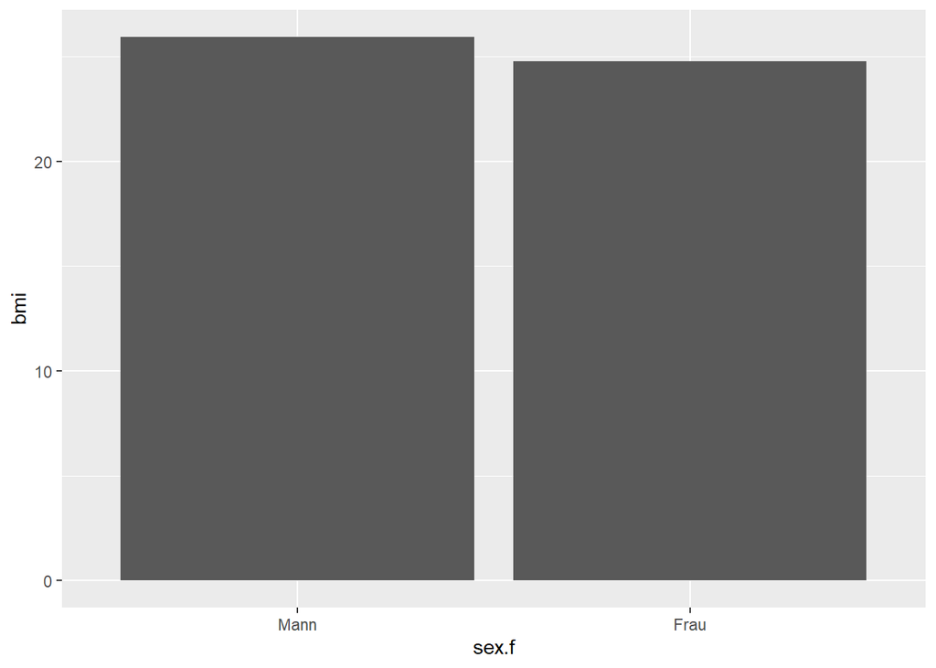

```r
ggplot(data = out, mapping = aes(x = sex.f, y = bmi)) +
  geom_col() +
  labs(y =  "bmi")
```

### Untere und obere Spalten (*±2SE*) zu out hinzufügen

```r
out_col <- mutate(out,
                  lower = bmi - 2*se,
                  upper = bmi + 2*se)
```

### Balkendiagramm des durchschnittlichen bmi nach Geschlecht mit Fehlerbalken

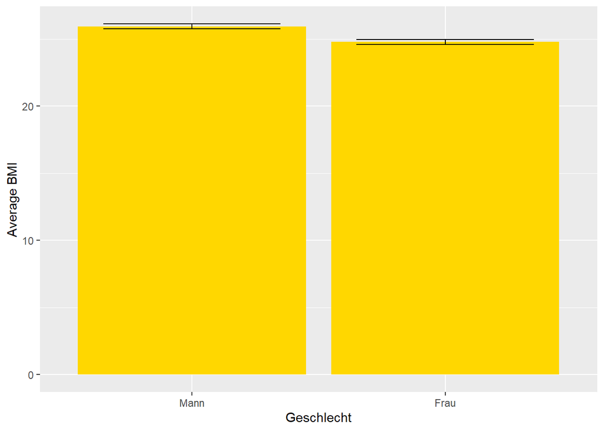

```r
ggplot(data = out_col,
       mapping = aes(x = sex.f, y = bmi,
                     ymin = lower, ymax = upper)) +
  geom_col(fill = "gold") +
  labs(y = "Average BMI", x = "Geschlecht") +
  geom_errorbar(width = 0.7)
```

### Histogramm mit einer festgelegten Bin-Breite (0,5), ü60

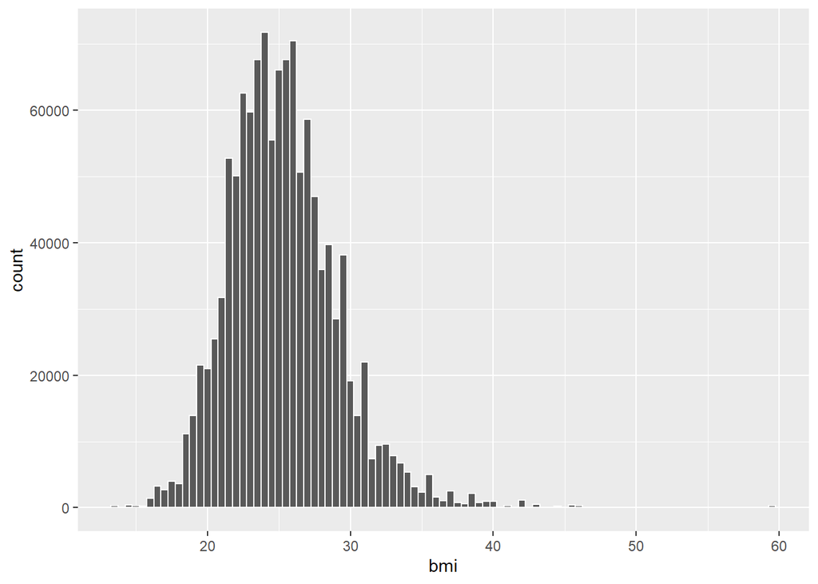

```r
ggplot(data = subset(dat_07, alter >= 60),
       mapping = aes(x = bmi, weight = wght)) +
  geom_histogram(binwidth = 0.5,
                 color = "white") +
  labs(x = "bmi")
```

### Dichtediagramm von bmi facettiert nach Geschlecht ü60

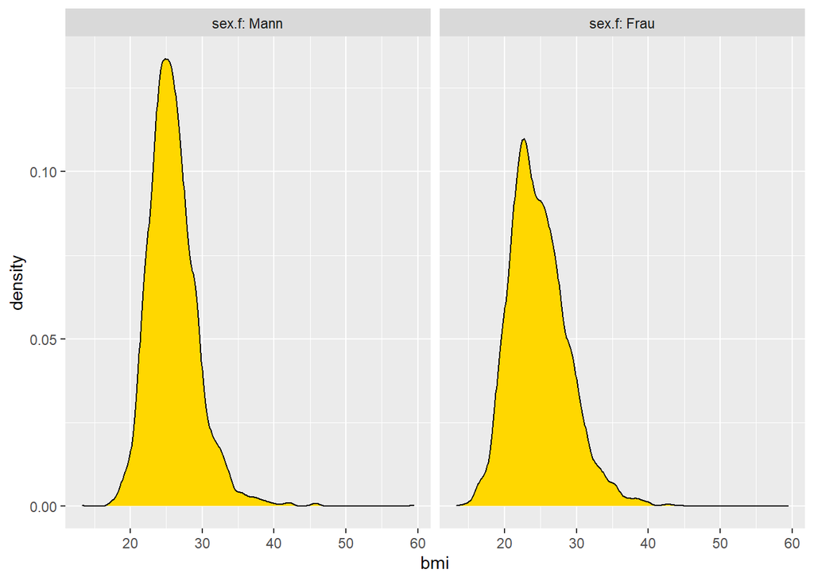

```r
subset(dat_07, alter >= 60) %>%
  filter(!is.na(bmi), !is.na(sex.f)) %>%
  group_by(sex.f) %>%
  mutate(wght_std = wght/sum(wght)) %>%
  ggplot(mapping = aes(x = bmi, weight = wght_std)) +
  geom_density(bw = 0.6,  fill = "gold") +
  labs(x = "bmi") +
  facet_wrap(~sex.f, labeller = "label_both")
```

### Umfragegewichteter t-Test bmi, nach Geschlecht ü60

```r
svyttest(formula = bmi ~ sex.f,
         design = subset(wdat_07, alter >= 60))
```

```
##
##  Design-based t-test
##
## data:  bmi ~ sex.f
## t = -8.8456, df = 4657, p-value < 2.2e-16
## alternative hypothesis: true difference in mean is not equal to 0
## 95 percent confidence interval:
##  -1.4186676 -0.9040176
## sample estimates:
## difference in mean
##          -1.161343
```

### Erstellen eines Datensatzes mit nur über 60-jährigen

```r
dat_07_60 <- filter(dat_07,
                   alter >= 60)
```

### Streudiagramm bmi nach Gender ü60

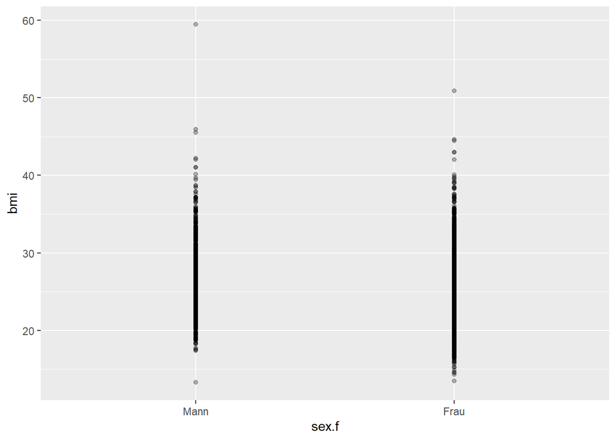

```r
ggplot(data = dat_07_60,
       mapping = aes(x = sex.f, y = bmi)) +
  geom_point(alpha = 0.3) +
  guides(size = FALSE)
```

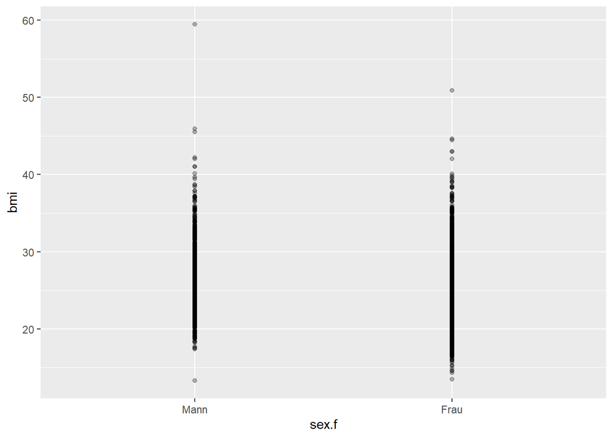

```r
ggplot(data = dat_07_60,
       mapping = aes(x = sex.f, y = bmi, weight = wght)) +
  geom_point(alpha = 0.3) +
  guides(size = FALSE)
```

### Streudiagramm (Farbe = Gewichtung)

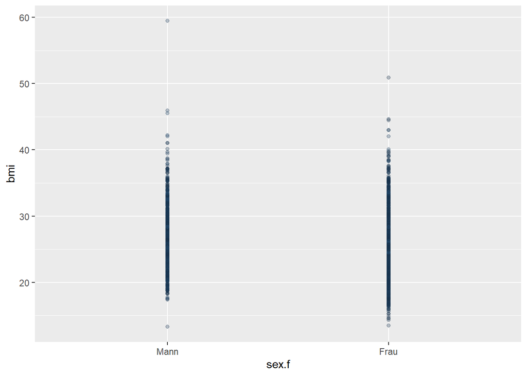

```r
ggplot(data = dat_07_60,
       mapping = aes(x = sex.f, y = bmi, colour = wght)) +
  geom_point(alpha = 0.3) +
  guides(colour = FALSE)
```

### Streudiagramm (alpha/transparaent = Gewichtung)

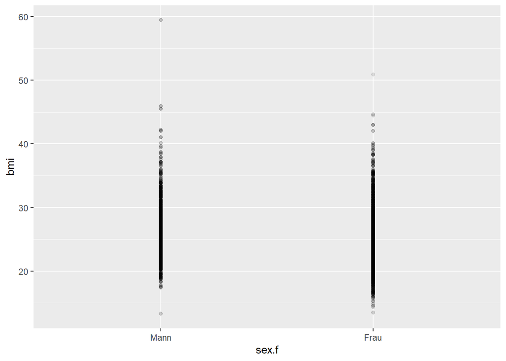

```r
ggplot(data = dat_07_60,
       mapping = aes(x = sex.f, y = bmi, alpha = wght)) +
  geom_point() +
  guides(alpha = FALSE)
```

### Geschlecht zum Plot hinzufügen

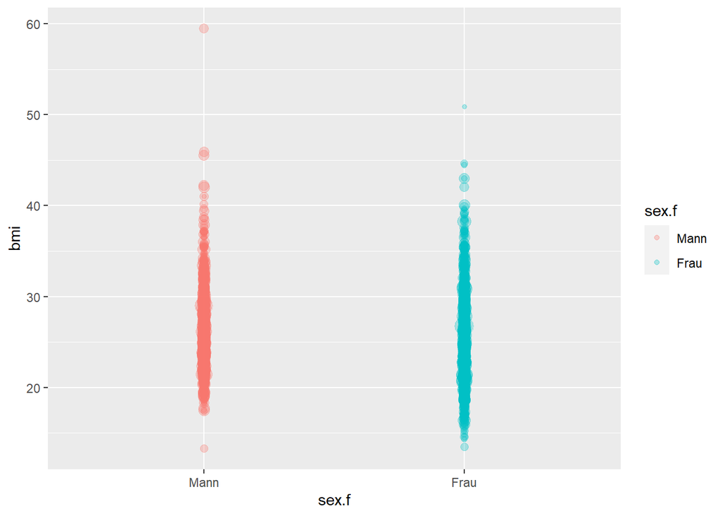

```r
ggplot(data = dat_07_60,
       mapping = aes(x = sex.f, y = bmi, size = wght, colour = sex.f)) +
  geom_point(alpha = 0.3) +
  guides(size = FALSE)
```

### Alter zum Plot hinzufügen

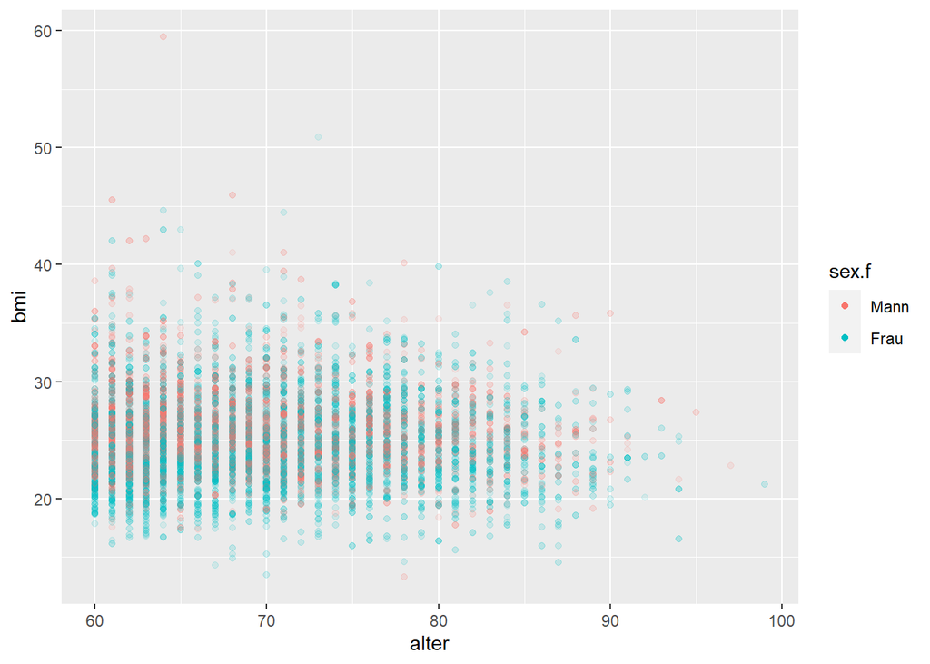

```r
ggplot(data = dat_07_60,
       mapping = aes(x = alter, y = bmi, alpha = wght, color = sex.f)) +
  geom_point() +
  guides(alpha = FALSE)
```

### Blasenplot mit bester linearer Anpassung

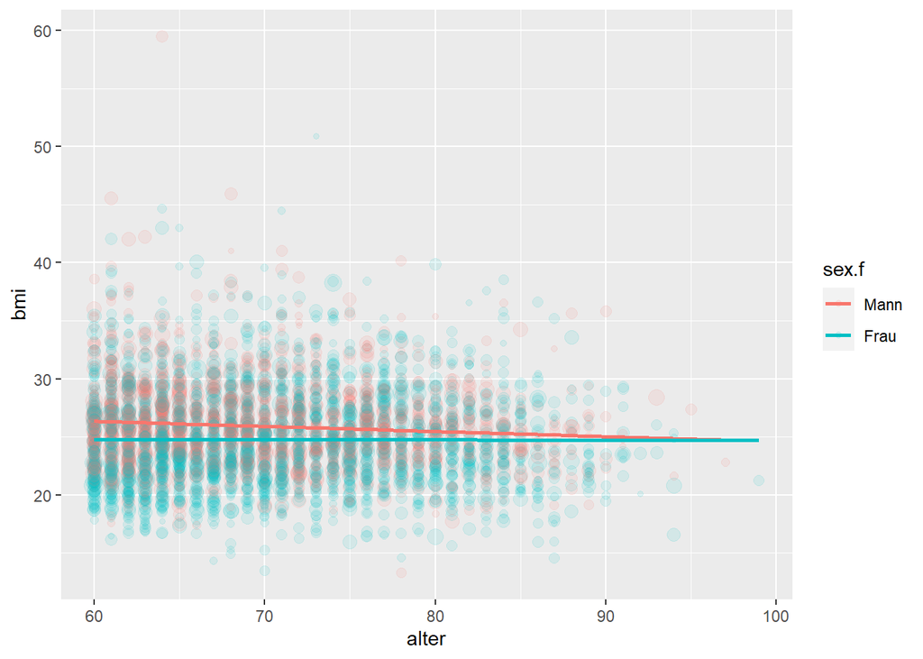

```r
ggplot(data = dat_07_60, mapping = aes(x = alter, y = bmi, size = wght, color = sex.f)) +
  geom_point(alpha = 0.1) +
  guides(size = FALSE) +
  geom_smooth(method = "lm", se = FALSE, mapping = aes(weight = wght))
```

# Beispiel für Quadratische Kurve und kubische Kurve bei bspw. Gewicht (tgezu02) ~ Alter hinzufügen

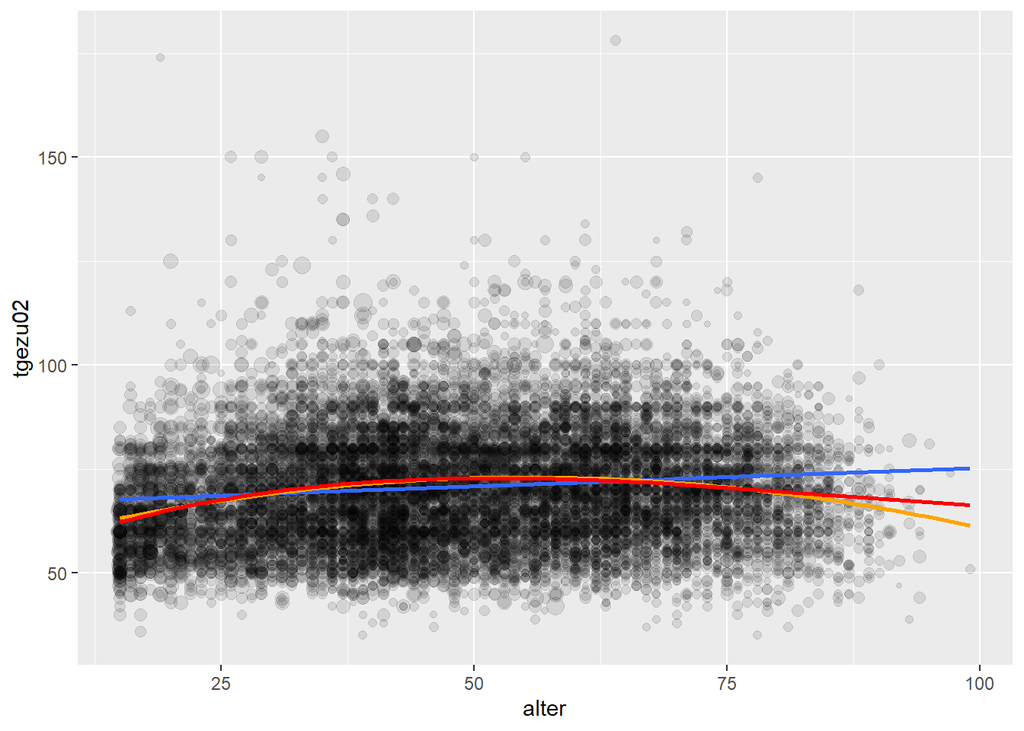

```r
ggplot(data = dat_07, mapping = aes(x = alter, y = tgezu02, size = wght)) +
  geom_point(alpha = 0.1) +
  guides(size = FALSE) +
  geom_smooth(method = "lm", se = FALSE, mapping = aes(weight = wght)) +
  geom_smooth(method = "lm", se = FALSE, mapping = aes(weight = wght), formula = y ~ poly(x, 2), color = "orange") +
  geom_smooth(method = "lm", se = FALSE, mapping = aes(weight = wght), formula = y ~ poly(x, 3), color = "red")
```

### Hinzufügen von nicht-survey-gewichtete Trendlinien zum Blasendiagramm Gewicht (tgezu02), Höhe (tgezu01)

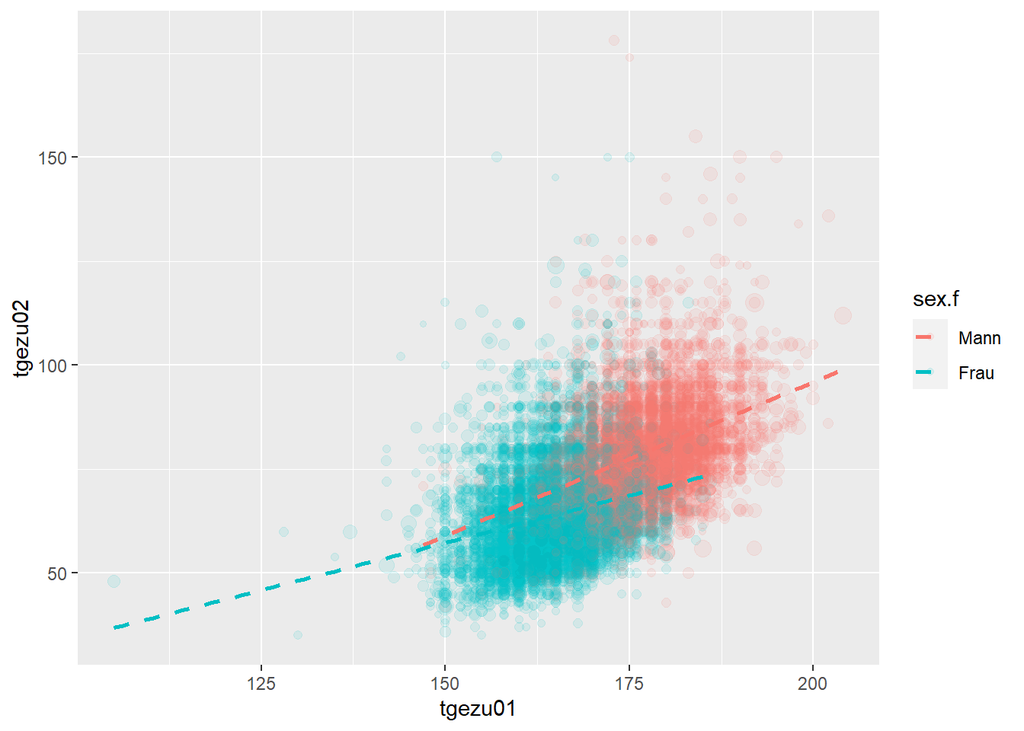

```r
ggplot(data = dat_07, mapping = aes(x = tgezu01, y = tgezu02, size = wght, color = sex.f)) +
  geom_point(alpha = 0.1) +
  guides(size = FALSE) +
  geom_smooth(method = "lm", se = FALSE, linetype = 2)
```

### Vergleich nach hinzufügen der Umfrage-gewichtete Trendlinien

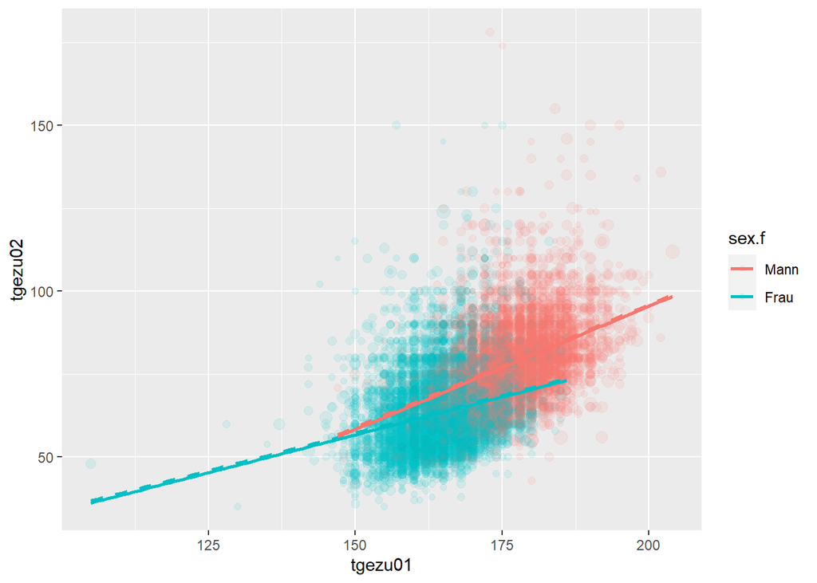

```r
ggplot(data = dat_07, mapping = aes(x = tgezu01, y = tgezu02, size = wght, color = sex.f)) +
  geom_point(alpha = 0.1) +
  guides(size = FALSE) +
  geom_smooth(method = "lm", se = FALSE, linetype = 2) +
  geom_smooth(method = "lm", se = FALSE, mapping = aes(weight = wght))
```

### Regressionsmodell am Beispiel: Gewicht (tgezu02), Höhe (tgezu01)

```r
mod <- svyglm(tgezu02 ~ tgezu01, design = wdat_07)
```

- Ausgabe des Modells

```r
summary(mod)
```

```
##
## Call:
## svyglm(formula = tgezu02 ~ tgezu01, design = wdat_07)
##
## Survey design:
## svydesign(id = ~idno, strata = ~kanton, weights = ~wght, nest = T,
##     data = dat_07)
##
## Coefficients:
##              Estimate Std. Error t value Pr(>|t|)
## (Intercept) -80.47061    2.47756  -32.48   <2e-16 ***
## tgezu01       0.88527    0.01458   60.73   <2e-16 ***
## ---
## Signif. codes:  0 '***' 0.001 '**' 0.01 '*' 0.05 '.' 0.1 ' ' 1
##
## (Dispersion parameter for gaussian family taken to be 132.0252)
##
## Number of Fisher Scoring iterations: 2
```

### Linearen Regressionsmodells mit verschiedenen Steigungen

```r
mod2 <- svyglm(tgezu02 ~ tgezu01 * sex.f, design = wdat_07)
```

- Ausgabe des Modells mit verschiedenen Steigungen

```r
summary(mod2)
```

```
##
## Call:
## svyglm(formula = tgezu02 ~ tgezu01 * sex.f, design = wdat_07)
##
## Survey design:
## svydesign(id = ~idno, strata = ~kanton, weights = ~wght, nest = T,
##     data = dat_07)
##
## Coefficients:
##                    Estimate Std. Error t value Pr(>|t|)
## (Intercept)       -53.08261    4.85341 -10.937  < 2e-16 ***
## tgezu01             0.74285    0.02756  26.951  < 2e-16 ***
## sex.fFrau          41.33863    6.26827   6.595 4.41e-11 ***
## tgezu01:sex.fFrau  -0.28664    0.03657  -7.837 4.93e-15 ***
## ---
## Signif. codes:  0 '***' 0.001 '**' 0.01 '*' 0.05 '.' 0.1 ' ' 1
##
## (Dispersion parameter for gaussian family taken to be 123.1533)
##
## Number of Fisher Scoring iterations: 2
```

## Einige Basisfunktionen im Überblick

- table taltp_1 & sex

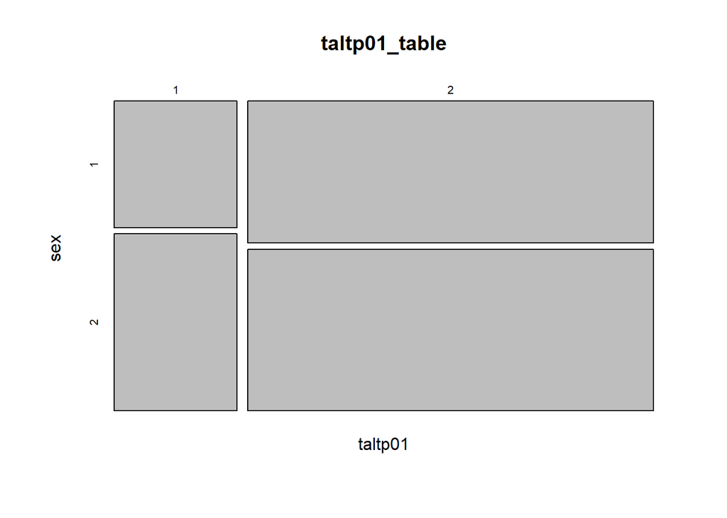

```r
taltp01_table<-svytable(~taltp01+sex, wdat_07)
plot(taltp01_table)
```

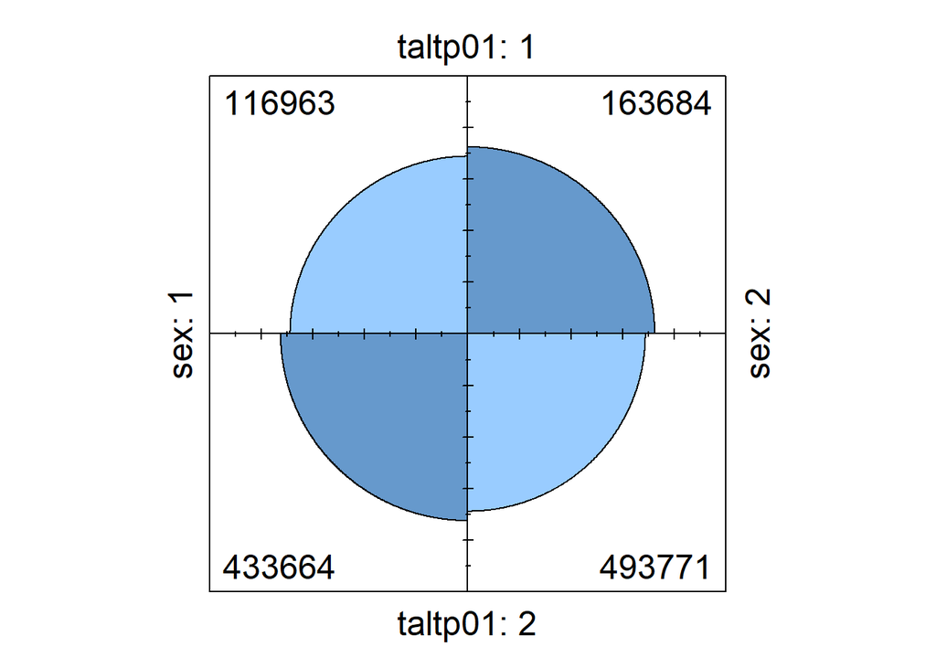

```r
fourfoldplot(svytable(~taltp01+sex, wdat_07, round = T), conf.level=0)
```

- survey mean of variable taltp_1, 2 (Sturz-Variablen), taltp03 kommt im 07 nicht vor

```r
svymean(~taltp01 + taltp02, wdat_07, na.rm = T, deff = TRUE)
```

```
##               mean         SE       DEff
## taltp01 1.0000e+00 4.0360e-18 1.1927e+32
## taltp02 1.4937e+00 2.7968e-02 1.5336e+00
```

```r
svymean(~taltp03, wdat_07, na.rm = T, deff = TRUE)
```

```
##         mean SE DEff
## taltp03    0  0   NA
```

- survey quantile of variable taltp_1-3

```r
svyquantile(~taltp01 + taltp02, wdat_07, quantiles = c(0.25, 0.5, 0.75), na.rm = T)
```

```
##         0.25 0.5 0.75
## taltp01    1   1    1
## taltp02    1   1    2
```

- survey ratio (nur ein Beispiel)

```r
svyratio(~bmi, ~alter, wdat_07, na.rm =T)
```

```
## Ratio estimator: svyratio.survey.design2(~bmi, ~alter, wdat_07, na.rm = T)
## Ratios=
##         alter
## bmi 0.5198391
## SEs=
##           alter
## bmi 0.002067728
```

- Untergruppen machen mit subset()

```r
svymean(~bmi, subset(wdat_07, sex ==1), na.rm = T)
```

```
##       mean     SE
## bmi 25.015 0.0573
```

```r
svymean(~bmi, subset(wdat_07, sex ==2), na.rm = T)
```

```
##       mean     SE
## bmi 23.377 0.0588
```

- svyby() Funktion für mehrere Outputs

```r
a<-svyby(~taltp01 + taltp02, ~alter, wdat_07, svymean, deff = T, vartype = c("se", "cv", "cvpct", "var"), na.rm =T, drop.empty.groups = F)
svyby(~alter, ~taltp01, wdat_07, svytotal)
```

```
##   taltp01    alter        se
## 1       1 19996849  718099.9
## 2       2 64648727 1187005.1
```

# Crosstabs; ftable(name_gespeicherter_output); tail( ,wieviel Zeilen)

```r
tail(ftable(a), 12)
```

```
##
##  "97"    "svymean"    0.000000e+00 0.000000e+00
##          "SE"         0.000000e+00 0.000000e+00
##          "cv"                  NaN          NaN
##          "cv%"                 NaN          NaN
##          "Var"        0.000000e+00 0.000000e+00
##          "DEff"                NaN          NaN
##  "99"    "svymean"    1.000000e+00 1.000000e+00
##          "SE"         0.000000e+00 0.000000e+00
##          "cv"         0.000000e+00 0.000000e+00
##          "cv%"        0.000000e+00 0.000000e+00
##          "Var"        0.000000e+00 0.000000e+00
##          "DEff"                NaN          NaN
```

- testing in tables; svychisq(~variable_1 + variable_2, daten)
- Beispiel eines Plots

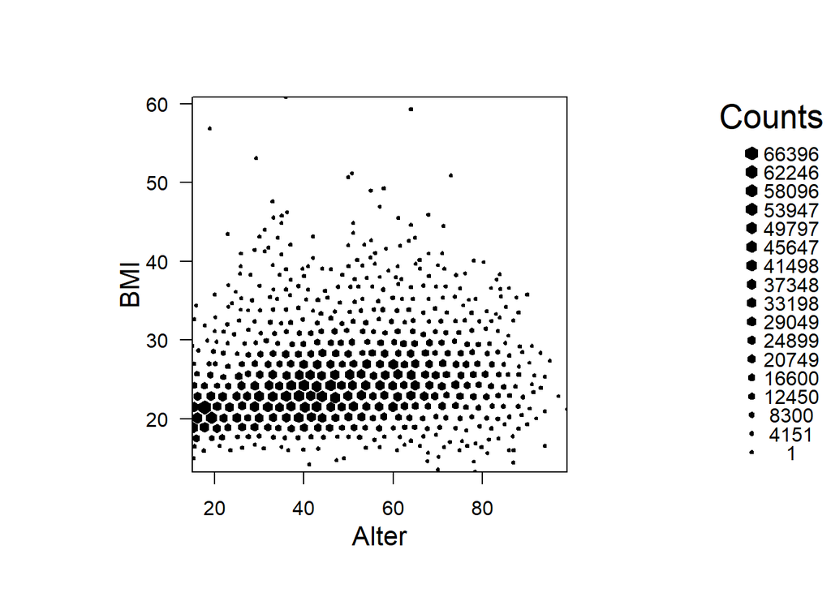

```r
library(hexbin)
svyplot(bmi~alter, style = "hex", design = wdat_07, xlab = "Alter", ylab = "BMI")
```

## GLM Modell

```r
bsp.glm<-svyglm(taltp01~alter+bmi+ausbild+sex, wdat_07)
summary(bsp.glm)
```

```
##
## Call:
## svyglm(formula = taltp01 ~ alter + bmi + ausbild + sex, design = wdat_07)
##
## Survey design:
## svydesign(id = ~idno, strata = ~kanton, weights = ~wght, nest = T,
##     data = dat_07)
##
## Coefficients:
##              Estimate Std. Error t value Pr(>|t|)
## (Intercept)  2.261430   0.101015  22.387  < 2e-16 ***
## alter       -0.004769   0.001057  -4.513 6.55e-06 ***
## bmi         -0.002268   0.001973  -1.150  0.25040
## ausbild     -0.003822   0.001855  -2.060  0.03946 *
## sex         -0.045607   0.016889  -2.700  0.00695 **
## ---
## Signif. codes:  0 '***' 0.001 '**' 0.01 '*' 0.05 '.' 0.1 ' ' 1
##
## (Dispersion parameter for gaussian family taken to be 0.1407085)
##
## Number of Fisher Scoring iterations: 2
```